# Preliminary Analysis

Bradley Hopkins, Matthew Hoctor

2/6/2021

# 1 Project overview

A project overview can be found in the README.md document on the main github project page: [link](https://github.com/matthew-hoctor/BSTA512-Project)

# 2 Import the dataset

Import the maternal smoking dataset:

```r
CHDS <- read.csv("CHDS.csv")
```

# 3 Descriptions of individual variables

## 3.1 Summary statistics for each variable:

```r
summary(CHDS)
```

```
##       bwt            gestwks           age            mnocig
##  Min.   : 3.300   Min.   :29.00   Min.   :15.00   Min.   : 0.000
##  1st Qu.: 6.800   1st Qu.:39.00   1st Qu.:21.00   1st Qu.: 0.000
##  Median : 7.600   Median :40.00   Median :25.00   Median : 0.000
##  Mean   : 7.516   Mean   :39.77   Mean   :25.86   Mean   : 7.431
##  3rd Qu.: 8.200   3rd Qu.:41.00   3rd Qu.:29.00   3rd Qu.:12.000
##  Max.   :11.400   Max.   :48.00   Max.   :42.00   Max.   :50.000
##     mheight          mppwt
##  Min.   :57.00   Min.   : 85.0
##  1st Qu.:63.00   1st Qu.:115.0
##  Median :64.00   Median :125.0
##  Mean   :64.43   Mean   :126.9
##  3rd Qu.:66.00   3rd Qu.:135.0
##  Max.   :71.00   Max.   :246.0
```

## 3.2 Birth Weight plots

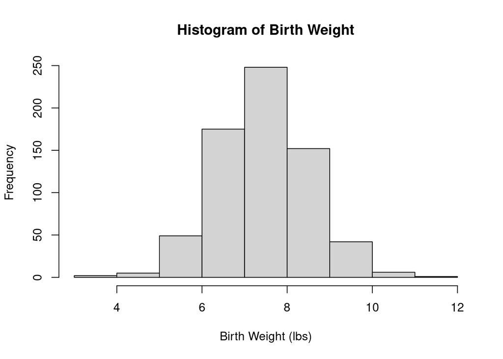

```r
hist(CHDS$bwt, main = paste("Histogram of Birth Weight"), xlab = "Birth Weight (lbs)")
```

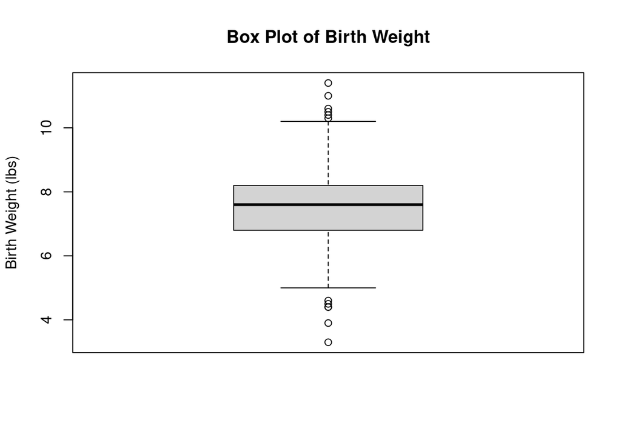

```r
boxplot(CHDS$bwt, main = "Box Plot of Birth Weight", ylab = "Birth Weight (lbs)")
```

## 3.3 Gestational age plots

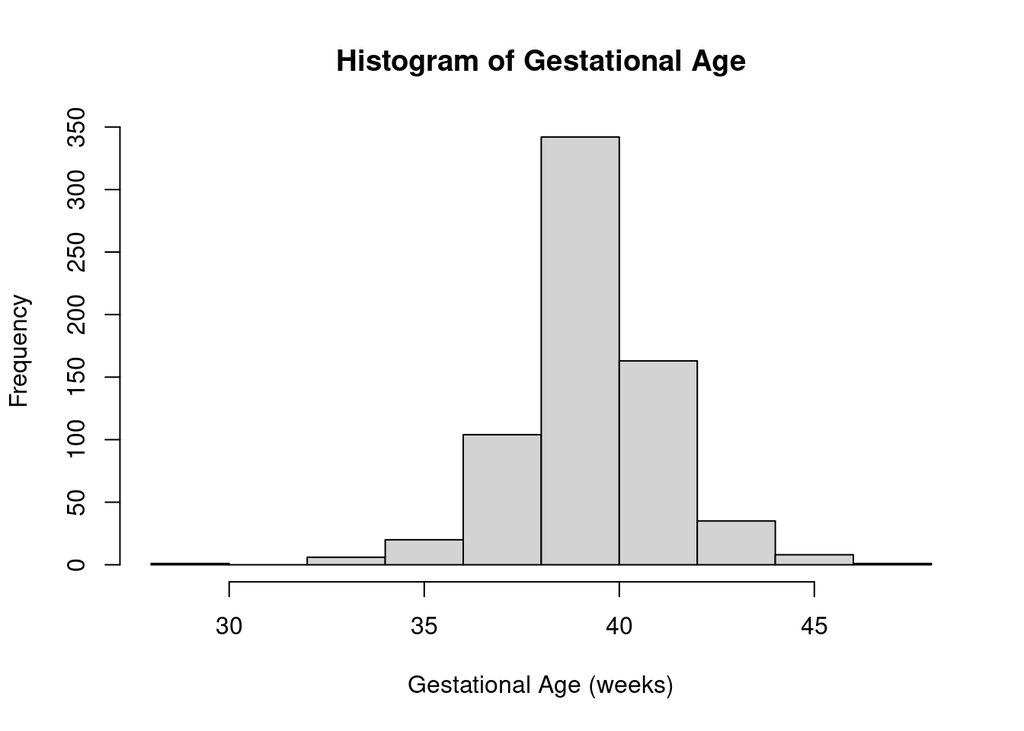

```r
hist(CHDS$gestwks, main = paste("Histogram of Gestational Age"), xlab = "Gestational Age (weeks)")
```

[figure not shown]

```r
boxplot(CHDS$bwt, main = "Box Plot of Gestational Age", ylab = "Gestational Age (weeks)")
```

## 3.4 Maternal Age plots

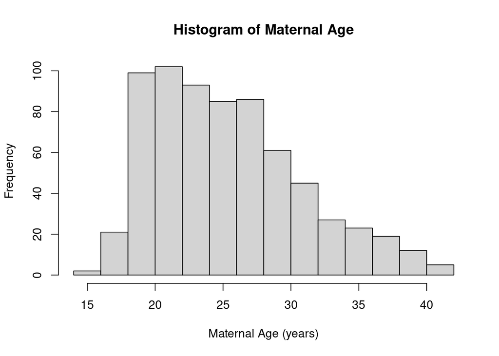

```r
hist(CHDS$age, main = paste("Histogram of Maternal Age"), xlab = "Maternal Age (years)")
```

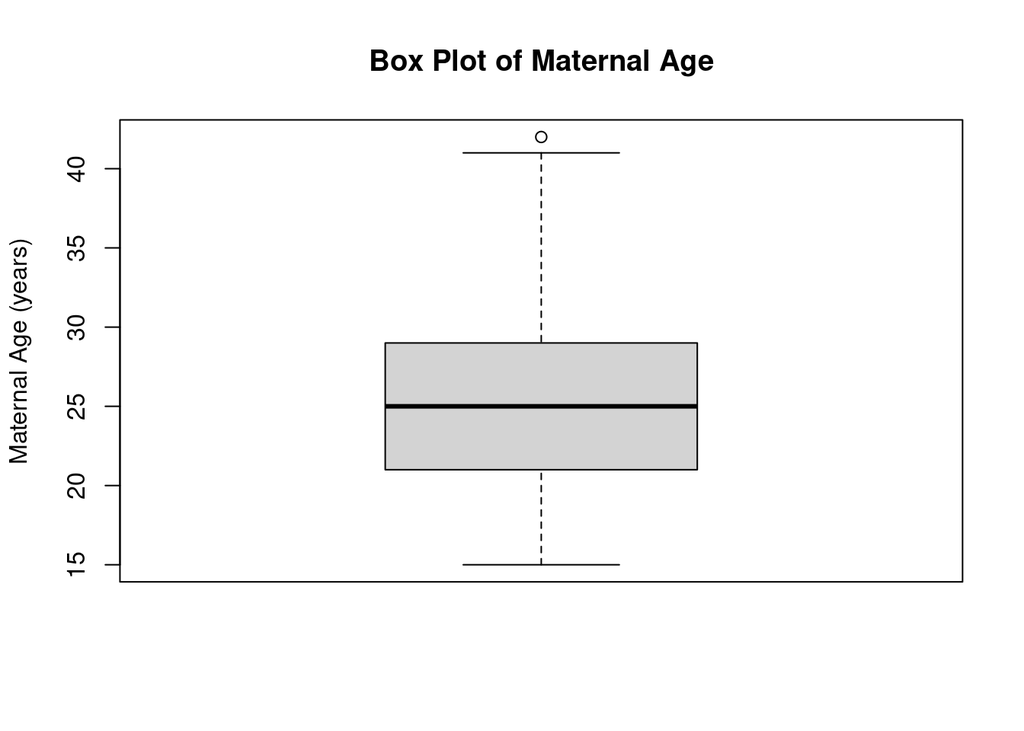

```r
boxplot(CHDS$age, main = "Box Plot of Maternal Age", ylab = "Maternal Age (years)")
```

## 3.5 Cigarettes smoked plots

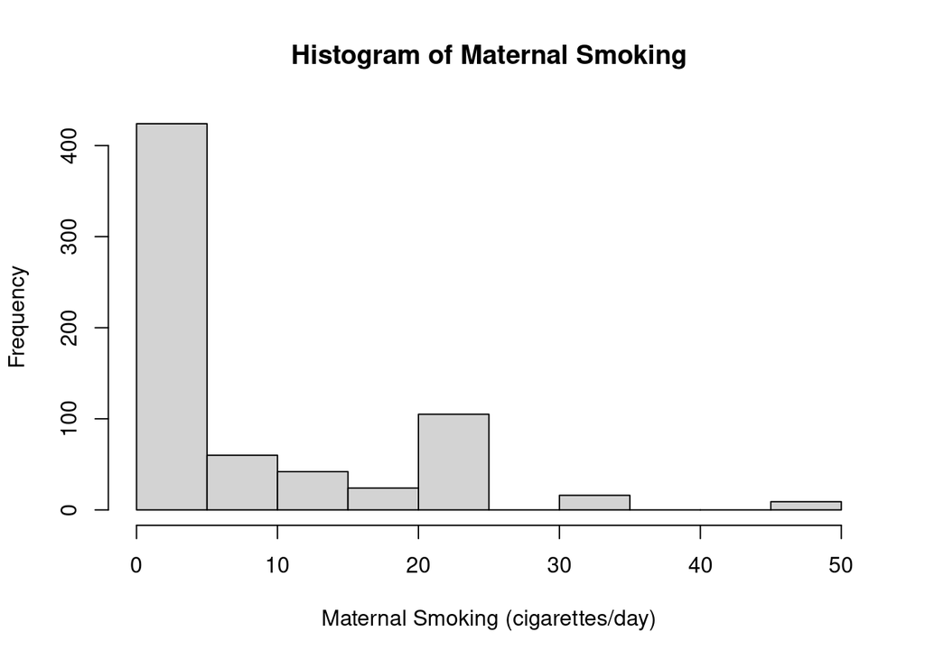

```r
hist(CHDS$mnocig, main = paste("Histogram of Maternal Smoking"), xlab = "Maternal Smoking (cigarettes/day)")
```

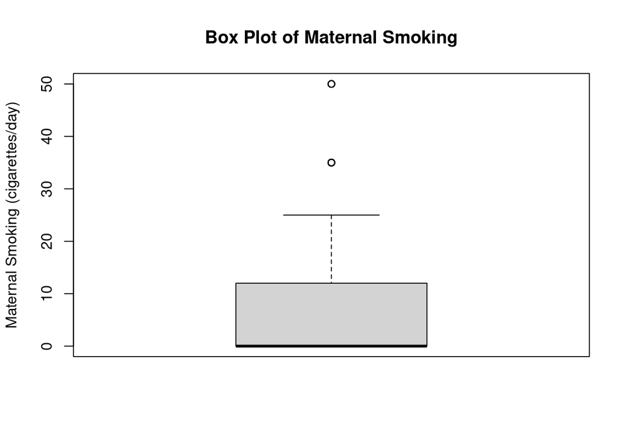

```r
boxplot(CHDS$mnocig, main = "Box Plot of Maternal Smoking", ylab = "Maternal Smoking (cigarettes/day)")
```

## 3.6 Maternal height plots

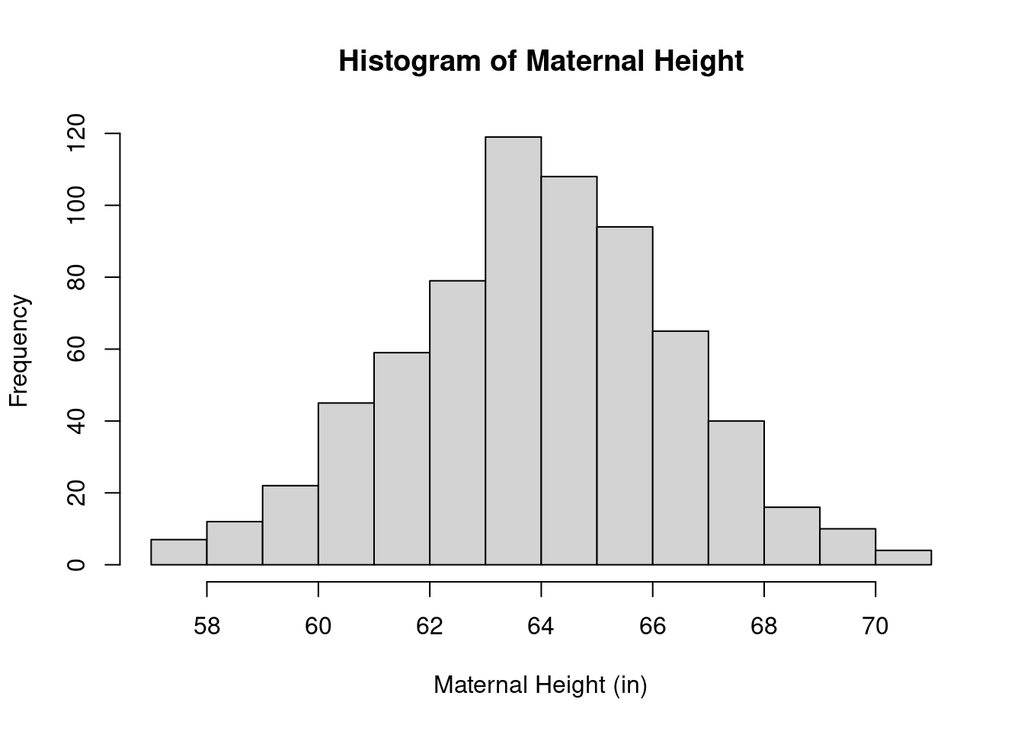

```r
hist(CHDS$mheight, main = paste("Histogram of Maternal Height"), xlab = "Maternal Height (in)")
```

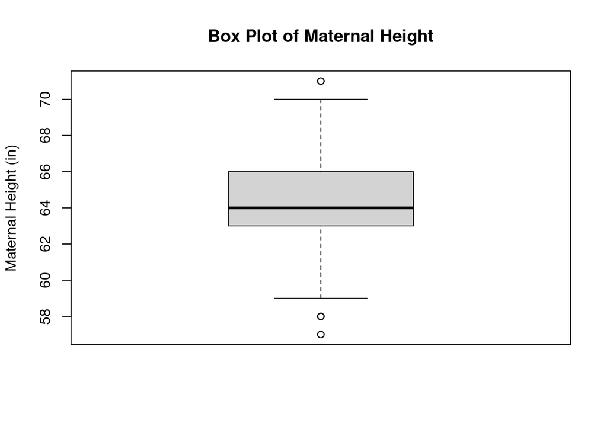

```r
boxplot(CHDS$mheight, main = "Box Plot of Maternal Height", ylab = "Maternal Height (in)")
```

## 3.7 Maternal pre-partum weight plots

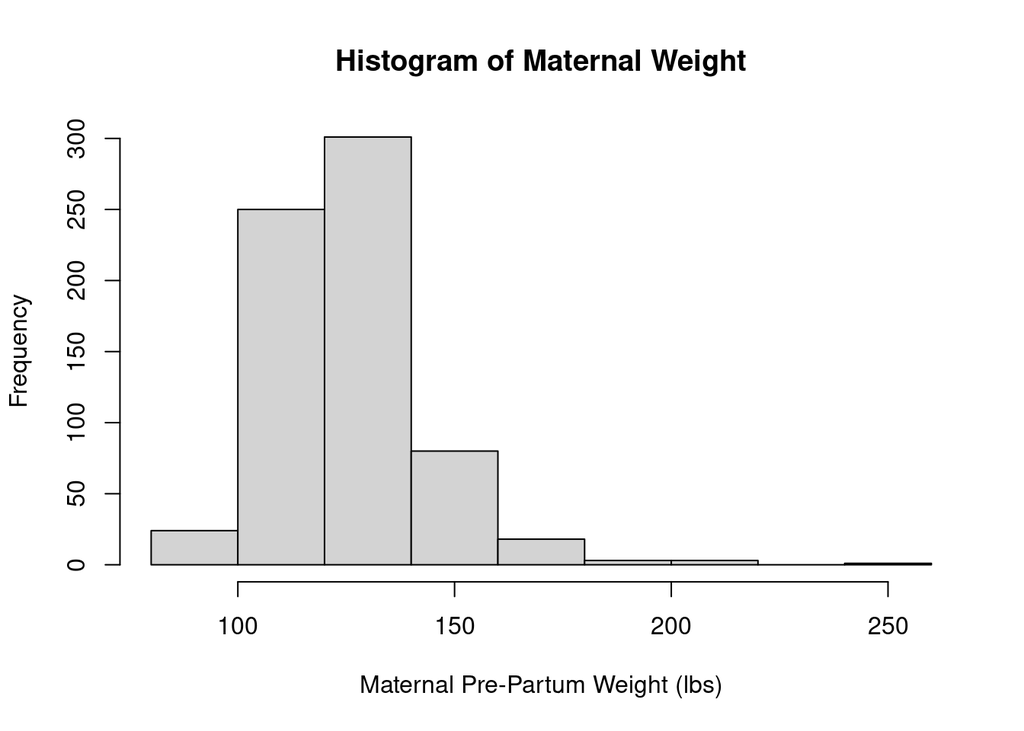

```r
hist(CHDS$mppwt, main = paste("Histogram of Maternal Weight"), xlab = "Maternal Pre-Partum Weight (lbs)")
```

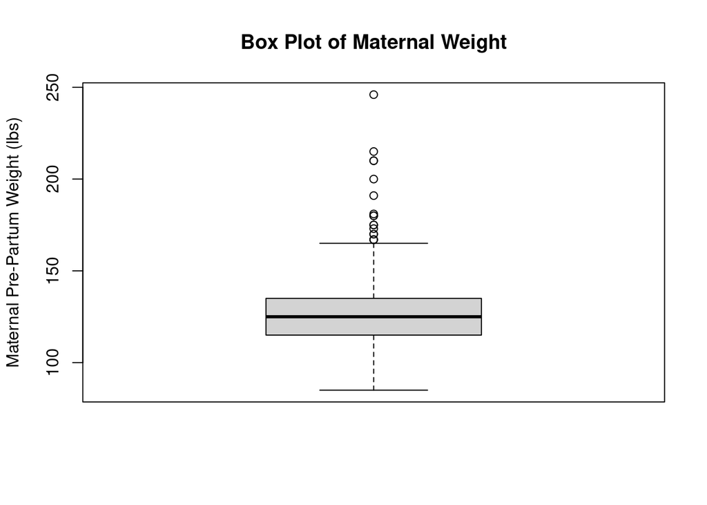

```r
boxplot(CHDS$mppwt, main = "Box Plot of Maternal Weight", ylab = "Maternal Pre-Partum Weight (lbs)")
```

# 4 Generation of new variables of interest

## 4.1 BMI

The following R Code creates a new variable for body mass index from the maternal weight and pre-partum height data:

```r
CHDS$BMI <- 703 * CHDS$mppwt / ((CHDS$mheight)^2)
```

## 4.2 BMI category

The following R code creates a new variable for BMI category:

```r
CHDS$BMI_cat <-
  ifelse(CHDS$BMI < 18.5, 0,
  ifelse(CHDS$BMI < 25, 1,
  ifelse(CHDS$BMI < 30, 2,
  ifelse(CHDS$BMI < 35, 3,
  ifelse(CHDS$BMI < 40, 4,
  5)))))
```

Note that 0 corresponds to underweight, 1 to normal weight, 2 to overweight, 3 to class I obese, 4 to class II obese, and 5 to class III obese.

## 4.3 Smoking category

The following R code creates a new variable for smoking category. Patients are categorized as 0, non-smokers; 1, light smokers 1-9 cigarettes/day; 2, moderate smokers, 10-19 cigarettes/day; or 3, heavy smokers 20+ cigarettes/day:

```r
CHDS$SMK_cat <-
  ifelse(CHDS$mnocig == 0, 0,
  ifelse(CHDS$mnocig < 10, 1,
  ifelse(CHDS$mnocig < 20, 2,
  3)))
```

# 5 Scatter plot matrix

The following R code creates a scatter plot matrix:

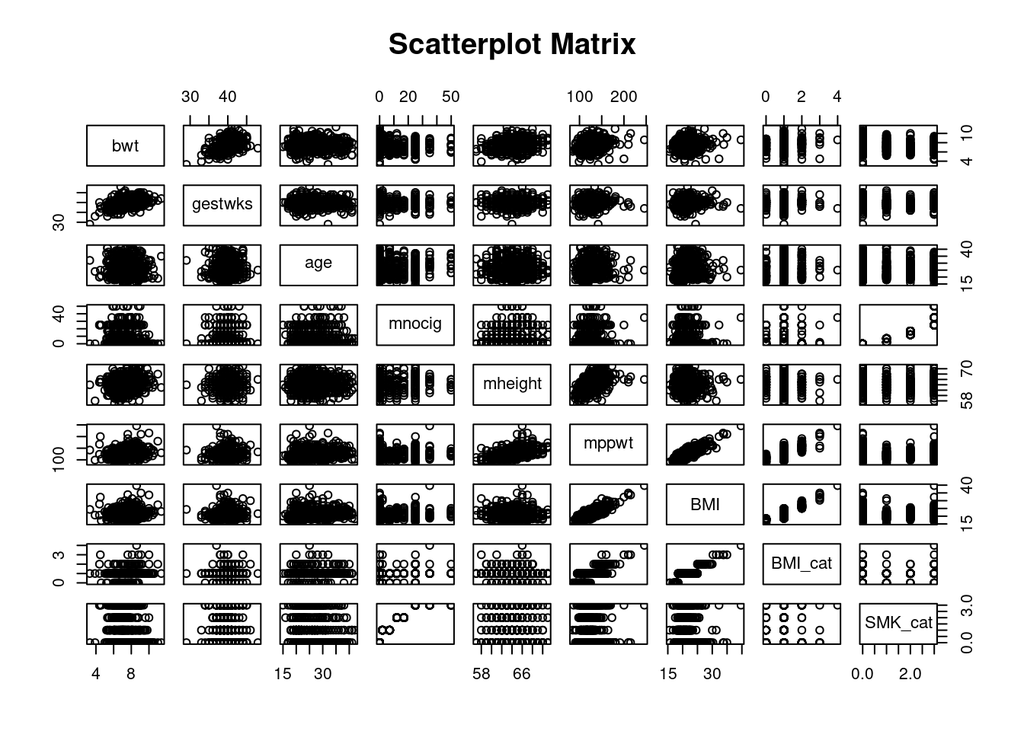

```r
pairs(~bwt+gestwks+age+mnocig+mheight+mppwt+BMI+BMI_cat+SMK_cat, data = CHDS, main = "Scatterplot Matrix")
```

# 6 Pairwise Correlation Matrix

```r
pwcorr(CHDS)
```

```
##                      bwt       gestwks           age        mnocig
## 1     bwt              1
## 2 gestwks  0.43\n(<0.01)             1
## 3     age      0\n(0.97)     0\n(0.93)             1
## 4  mnocig -0.18\n(<0.01) -0.07\n(0.06)  0.04\n(0.24)             1
## 5 mheight   0.2\n(<0.01)  0.05\n(0.21)  0.02\n(0.65)   0.03\n(0.5)
## 6   mppwt  0.22\n(<0.01)  0.05\n(0.18) 0.12\n(<0.01)  -0.03\n(0.5)
## 7     BMI  0.13\n(<0.01)   0.03\n(0.4) 0.12\n(<0.01) -0.05\n(0.21)
## 8 BMI_cat   0.1\n(<0.01)  0.04\n(0.29)  0.03\n(0.42)  0.04\n(0.33)
## 9 SMK_cat -0.21\n(<0.01) -0.07\n(0.05)     0\n(0.95) 0.94\n(<0.01)
##         mheight         mppwt           BMI      BMI_cat SMK_cat
## 1
## 2
## 3
## 4
## 5             1
## 6 0.49\n(<0.01)             1
## 7 -0.06\n(0.11) 0.84\n(<0.01)             1
## 8 -0.04\n(0.34) 0.68\n(<0.01) 0.81\n(<0.01)            1
## 9  0.01\n(0.79) -0.07\n(0.07) -0.09\n(0.02) 0.01\n(0.81)       1
```

# 7 Check normality of response data

## 7.1 Birth Weight

We can perform the Shapiro-Wilk test to to test for normality:

```r
shapiro.test(CHDS$bwt)
```

```
##
##  Shapiro-Wilk normality test
##
## data:  CHDS$bwt
## W = 0.99645, p-value = 0.133
```

This borderline p-value suggests that more investigation may be needed. A Q-Q plot and boxplot may help:

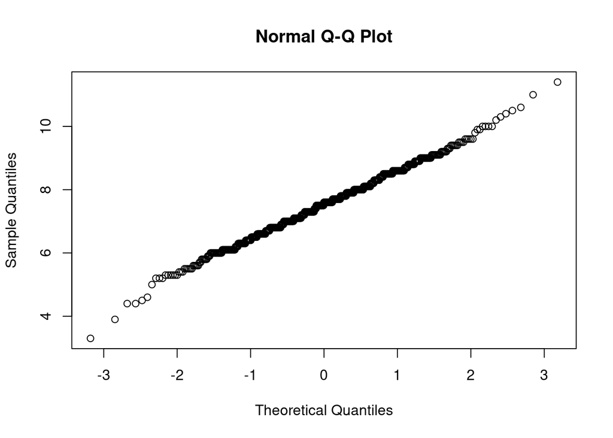

```r
qqnorm(CHDS$bwt)
```

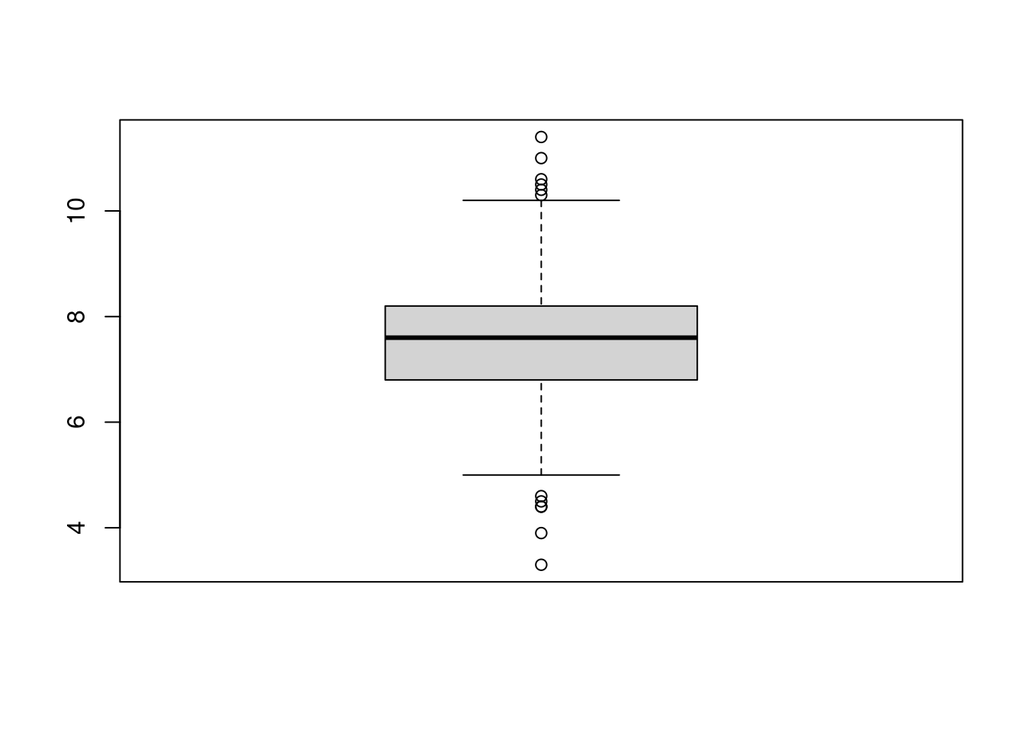

```r
boxplot(CHDS$bwt)
```

These results suggest that birth weight is normally distributed. For completeness we can check the gladder function:

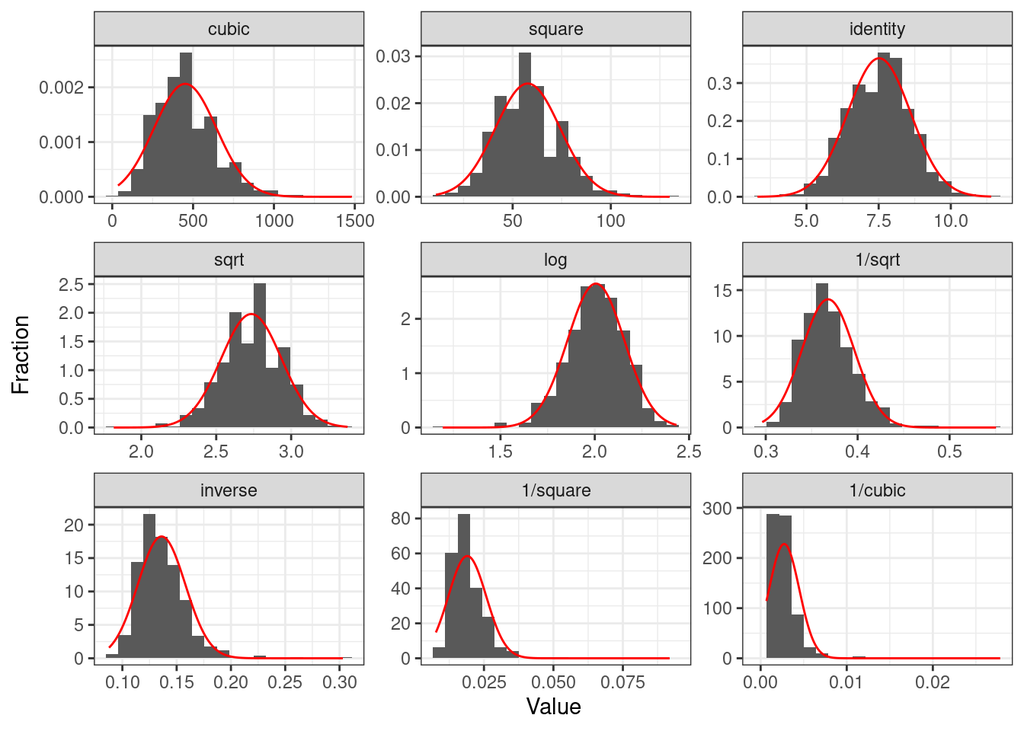

```r
gladder(CHDS$bwt)
```

None of the transformed distributions look particularly better than the origional distribution.

## 7.2 Gestational Age

We can perform the Shapiro-Wilk test to to test for normality:

```r
shapiro.test(CHDS$gestwks)
```

```
##
##  Shapiro-Wilk normality test
##
## data:  CHDS$gestwks
## W = 0.93902, p-value = 4.551e-16
```

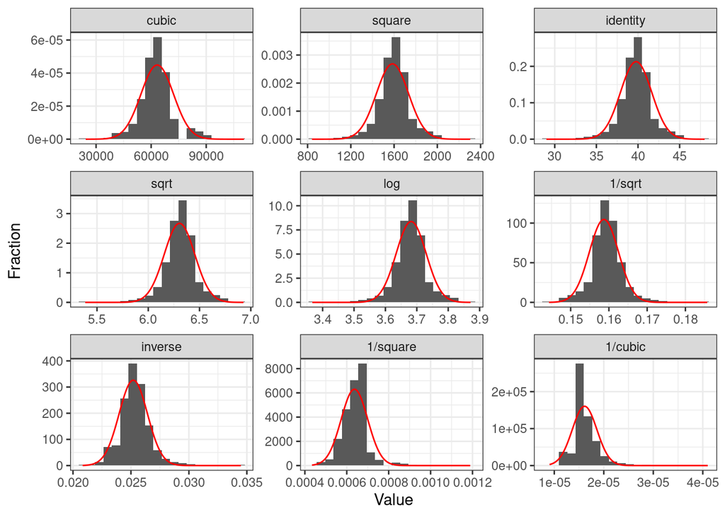

```r
gladder(CHDS$gestwks)
```

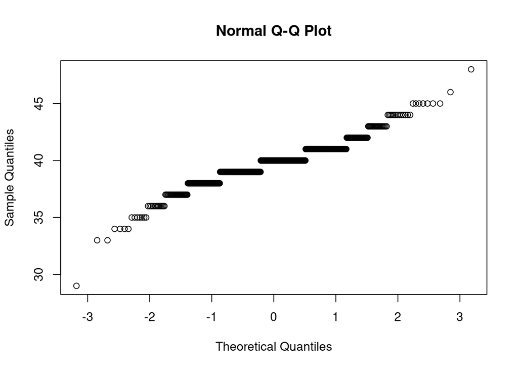

```r
qqnorm(CHDS$gestwks)
```

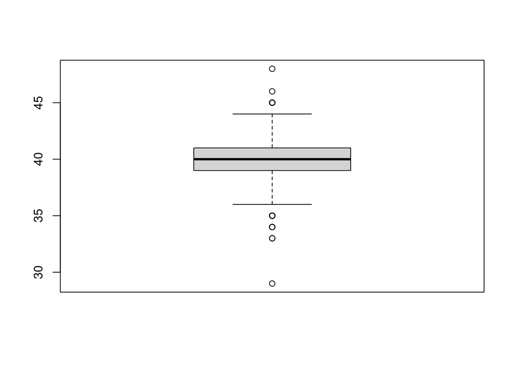

```r
boxplot(CHDS$gestwks)
```

# 8 Preliminary Exploratory analysis

The following code evaluates the the correlation coefficients for each of the variables used in the study:

```r
pcor(CHDS)$estimate
```

```
##                  bwt     gestwks          age       mnocig      mheight
## bwt      1.000000000  0.42104338 -0.022113163  0.035428811 -0.008273147
## gestwks  0.421043377  1.00000000  0.013115247 -0.020704678  0.040997469
## age     -0.022113163  0.01311525  1.000000000  0.116230228 -0.005037463
## mnocig   0.035428811 -0.02070468  0.116230228  1.000000000  0.004806437
## mheight -0.008273147  0.04099747 -0.005037463  0.004806437  1.000000000
## mppwt    0.034889198 -0.04703086  0.008245065  0.000565178  0.992472635
## BMI     -0.026128391  0.04181560  0.012905507  0.005292619 -0.985114977
## BMI_cat  0.010126202  0.02693642 -0.117662659  0.010357430 -0.001173643
## SMK_cat -0.098525595  0.02408128 -0.100835398  0.940905720 -0.013587523
##                mppwt          BMI      BMI_cat     SMK_cat
## bwt      0.034889198 -0.026128391  0.010126202 -0.09852560
## gestwks -0.047030858  0.041815595  0.026936421  0.02408128
## age      0.008245065  0.012905507 -0.117662659 -0.10083540
## mnocig   0.000565178  0.005292619  0.010357430  0.94090572
## mheight  0.992472635 -0.985114977 -0.001173643 -0.01358752
## mppwt    1.000000000  0.991423771  0.003685339  0.01053122
## BMI      0.991423771  1.000000000  0.101953565 -0.02251821
## BMI_cat  0.003685339  0.101953565  1.000000000  0.03782960
## SMK_cat  0.010531220 -0.022518208  0.037829597  1.00000000
```

Note that from the above output that the magnitude of the correlation of `bwt` with `mppwt` and `BMI` are almost as large as the magnitude of the correlation of `bwt` with `mcnocig`. Also worth noting is the magnitude of the correlation between `bwt` and `gestwks`, although this is not unexpected since birthweight is well documented to be associated with gestation age with much higher risk of low birth weight among pre-term infants.

## 8.1 Birth-weight and gestation weeks

```r
summary(lm(CHDS$bwt ~ CHDS$gestwks))
```

```
##
## Call:
## lm(formula = CHDS$bwt ~ CHDS$gestwks)
##
## Residuals:
##     Min      1Q  Median      3Q     Max
## -3.1734 -0.6253  0.0266  0.6276  3.3305
##
## Coefficients:
##              Estimate Std. Error t value Pr(>|t|)
## (Intercept)  -2.34818    0.80582  -2.914  0.00369 **
## CHDS$gestwks  0.24804    0.02024  12.255  < 2e-16 ***
## ---
## Signif. codes:  0 '***' 0.001 '**' 0.01 '*' 0.05 '.' 0.1 ' ' 1
##
## Residual standard error: 0.9891 on 678 degrees of freedom
## Multiple R-squared:  0.1814, Adjusted R-squared:  0.1801
## F-statistic: 150.2 on 1 and 678 DF,  p-value: < 2.2e-16
```

The output above shows that there is very highly statistically significant evidence (P < 0.001) for a linear relationship between `bwt` and `gestwks`.

## 8.2 Birth-weight and age

```r
summary(lm(CHDS$bwt ~ CHDS$age))
```

```
##
## Call:
## lm(formula = CHDS$bwt ~ CHDS$age)
##
## Residuals:
##     Min      1Q  Median      3Q     Max
## -4.2181 -0.7170  0.0804  0.6851  3.8811
##
## Coefficients:
##              Estimate Std. Error t value Pr(>|t|)
## (Intercept) 7.5097117  0.2029260  37.007   <2e-16 ***
## CHDS$age    0.0002614  0.0076786   0.034    0.973
## ---
## Signif. codes:  0 '***' 0.001 '**' 0.01 '*' 0.05 '.' 0.1 ' ' 1
##
## Residual standard error: 1.093 on 678 degrees of freedom
## Multiple R-squared:  1.709e-06,  Adjusted R-squared:  -0.001473
## F-statistic: 0.001159 on 1 and 678 DF,  p-value: 0.9729
```

The output above shows there is insufficient evidence (P = 0.9729) to suggest a linear relationship between birth-weight and age.

## 8.3 Birth-weight and cigarettes smoked per day

```r
summary(lm(CHDS$bwt ~ CHDS$mnocig))
```

```
##
## Call:
## lm(formula = CHDS$bwt ~ CHDS$mnocig)
##
## Residuals:
##     Min      1Q  Median      3Q     Max
## -4.3457 -0.7457 -0.0175  0.6976  3.7543
##
## Coefficients:
##              Estimate Std. Error t value Pr(>|t|)
## (Intercept)  7.645663   0.049406 154.751  < 2e-16 ***
## CHDS$mnocig -0.017386   0.003661  -4.749  2.5e-06 ***
## ---
## Signif. codes:  0 '***' 0.001 '**' 0.01 '*' 0.05 '.' 0.1 ' ' 1
##
## Residual standard error: 1.075 on 678 degrees of freedom
## Multiple R-squared:  0.03219,    Adjusted R-squared:  0.03076
## F-statistic: 22.55 on 1 and 678 DF,  p-value: 2.502e-06
```

The output above shows that there is very highly statistically significant evidence (P < 0.001) that there is a linear association between birthweight and number of cigarettes smoked per day by the mother.

## 8.4 Birth-weight and maternal height

```r
summary(lm(CHDS$bwt ~ CHDS$mheight))
```

```
##
## Call:
## lm(formula = CHDS$bwt ~ CHDS$mheight)
##
## Residuals:
##     Min      1Q  Median      3Q     Max
## -4.1778 -0.6833  0.0222  0.7113  4.0113
##
## Coefficients:
##              Estimate Std. Error t value Pr(>|t|)
## (Intercept)   1.77576    1.06676   1.665   0.0964 .
## CHDS$mheight  0.08909    0.01654   5.385 9.98e-08 ***
## ---
## Signif. codes:  0 '***' 0.001 '**' 0.01 '*' 0.05 '.' 0.1 ' ' 1
##
## Residual standard error: 1.07 on 678 degrees of freedom
## Multiple R-squared:  0.04102,    Adjusted R-squared:  0.03961
## F-statistic:    29 on 1 and 678 DF,  p-value: 9.976e-08
```

The output above shows that there is very highly statistically significant evidence (P < 0.001) that there is a linear association between birthweight and maternal height.

## 8.5 Birth-weight and maternal pre-pregnancy weight

```r
summary(lm(CHDS$bwt ~ CHDS$mppwt))
```

```
##
## Call:
## lm(formula = CHDS$bwt ~ CHDS$mppwt)
##
## Residuals:
##     Min      1Q  Median      3Q     Max
## -4.4210 -0.6892  0.0107  0.6800  3.8415
##
## Coefficients:
##             Estimate Std. Error t value Pr(>|t|)
## (Intercept) 5.798434   0.293231  19.774  < 2e-16 ***
## CHDS$mppwt  0.013539   0.002288   5.917 5.21e-09 ***
## ---
## Signif. codes:  0 '***' 0.001 '**' 0.01 '*' 0.05 '.' 0.1 ' ' 1
##
## Residual standard error: 1.066 on 678 degrees of freedom
## Multiple R-squared:  0.0491, Adjusted R-squared:  0.0477
## F-statistic: 35.01 on 1 and 678 DF,  p-value: 5.211e-09
```

The output above shows that there is very highly statistically significant evidence (P < 0.001) for a linear association between birthweight and maternal pre-pregnancy weight.

## 8.6 Birth-weight and maternal pre-pregnancy BMI

```r
summary(lm(CHDS$bwt ~ CHDS$BMI))
```

```
##
## Call:
## lm(formula = CHDS$bwt ~ CHDS$BMI)
##
## Residuals:
##     Min      1Q  Median      3Q     Max
## -4.3693 -0.7058  0.0108  0.7167  3.8015
##
## Coefficients:
##             Estimate Std. Error t value Pr(>|t|)
## (Intercept)  6.38694    0.34253  18.647  < 2e-16 ***
## CHDS$BMI     0.05262    0.01584   3.322 0.000941 ***
## ---
## Signif. codes:  0 '***' 0.001 '**' 0.01 '*' 0.05 '.' 0.1 ' ' 1
##
## Residual standard error: 1.084 on 678 degrees of freedom
## Multiple R-squared:  0.01602,    Adjusted R-squared:  0.01457
## F-statistic: 11.04 on 1 and 678 DF,  p-value: 0.0009409
```

The output above shows that there is very highly statistically significant evidence (P < 0.001) for a linear association between birth-weight and maternal pre-pregnancy BMI.

## 8.7 Birth-weight and maternal pre-pregnancy BMI with cigarettes smoked as control

```r
summary(lm(CHDS$bwt ~ CHDS$BMI + CHDS$mnocig))
```

```
##
## Call:
## lm(formula = CHDS$bwt ~ CHDS$BMI + CHDS$mnocig)
##
## Residuals:
##     Min      1Q  Median      3Q     Max
## -4.4842 -0.7097 -0.0094  0.7055  3.6819
##
## Coefficients:
##              Estimate Std. Error t value Pr(>|t|)
## (Intercept)  6.586817   0.340253  19.359  < 2e-16 ***
## CHDS$BMI     0.049132   0.015623   3.145  0.00173 **
## CHDS$mnocig -0.016833   0.003642  -4.622 4.55e-06 ***
## ---
## Signif. codes:  0 '***' 0.001 '**' 0.01 '*' 0.05 '.' 0.1 ' ' 1
##
## Residual standard error: 1.068 on 677 degrees of freedom
## Multiple R-squared:  0.04612,    Adjusted R-squared:  0.0433
## F-statistic: 16.37 on 2 and 677 DF,  p-value: 1.144e-07
```

Including `mnocig` in the model still provides significant evidence for the `BMI` correlation coefficient (0.001 < P < 0.01), although the magnitude of the coefficient has decreased slightly, from 0.05262 to 0.049132. The R<sup>2</sup> value for the model including both `BMI` and `mnocig` in the model is slightly higher than for when `BMI` is used alone, increasing from 0.01602 to 0.04612.

## 8.8 Birth-weight and maternal pre-pregnancy weight with cigarettes smoked as control

```r
summary(lm(CHDS$bwt ~ CHDS$mppwt + CHDS$mnocig))
```

```
##
## Call:
## lm(formula = CHDS$bwt ~ CHDS$mppwt + CHDS$mnocig)
##
## Residuals:
##     Min      1Q  Median      3Q     Max
## -4.5420 -0.6803 -0.0027  0.6549  3.7172
##
## Coefficients:
##              Estimate Std. Error t value Pr(>|t|)
## (Intercept)  5.958320   0.290739  20.494  < 2e-16 ***
## CHDS$mppwt   0.013265   0.002254   5.885 6.26e-09 ***
## CHDS$mnocig -0.016844   0.003575  -4.712 2.98e-06 ***
## ---
## Signif. codes:  0 '***' 0.001 '**' 0.01 '*' 0.05 '.' 0.1 ' ' 1
##
## Residual standard error: 1.05 on 677 degrees of freedom
## Multiple R-squared:  0.07929,    Adjusted R-squared:  0.07657
## F-statistic: 29.15 on 2 and 677 DF,  p-value: 7.171e-13
```

When `mnocig` is included in the model for `bwt` and `mppwt`, the magnitude of the coefficient for `mppwt` decreases slightly (from 0.013539 to 0.013265) and the significance level remains about the same. The R<sup>2</sup> value increases a fair amount from 0.0491 to 0.07929, suggesting this model is better able to explain the variance in `bwt` compared to the model of `mppwt` alone.

# 9 Export the modified dataset as a new .csv file

The following .csv file will be used for building the association model and prediction model:

```r
write.csv(CHDS, file = "CHDS2.csv")
```

# 10 References:

See [literature review section](https://github.com/matthew-hoctor/BSTA512-Project#literature-review)